# yhf_2

Previously, we scraped some adj close prices for a list of tickers. Assuming that these tickers are in our portfolio, let's calculate portfolio value. Our function will take in the adjusted close prices dataframe, the weights of each stock in our portfolio, and our initial cash.

We need to normalize all our adjusted close prices. We can do so by dividing each price by the first price in the dataframe (index 0). We then need to calculate our allocations, to do this we take our normalized dataframe and multiply it by the weights. We can then calculate our portfolio values by multiplying our allocations dataframe by our cash. We then sum the columns by using the function .sum(axis=1).

```python
import pandas as pd
import pandas_datareader.data as web
def get_adjusted_close(tickers,start,end):
    d = {} #our dictionary
    for ticker in tickers:
        d[ticker] = web.DataReader(ticker,"yahoo",start,end) #this will give us open, high, low, close, volume, Adj Close
    pan = pd.Panel(d)
    df_adj_close = pan.minor_xs('Adj Close')
    return df_adj_close

def Portfolio_Value(df_adj_close,weights,cash):
        normed = df_adj_close/df_adj_close.ix[0,:] #Norming the prices
        alloced = normed*weights #Creating our allocations
        pos_vals = alloced*cash  #Our portfolio value
        series_portfolio_value = pos_vals.sum(axis=1)  #Summing by row
        return series_portfolio_value


tickers = ['AAPL','BAC','GILD','MSFT']
start = '2016-01-01'
end = '2016-12-21'
df_adj_close = get_adjusted_close(tickers,start,end)
weights = [0.25,0.25,0.25,0.25]
cash = 100000
pv = Portfolio_Value(df_adj_close,weights,cash)
print pv
```

```
Date
2016-01-04    100000.000000
2016-01-05     99806.413433
2016-01-06     98605.944058
2016-01-07     94824.145538
2016-01-08     94612.697252
2016-01-11     95151.709299
2016-01-12     95863.077400
2016-01-13     92946.127407
2016-01-14     94381.585701
2016-01-15     91739.835094
2016-01-19     90602.535509
2016-01-20     90067.227374
2016-01-21     88878.867032
2016-01-22     91978.940647
2016-01-25     90056.820682
2016-01-26     91301.376737
2016-01-27     88726.878305
2016-01-28     88992.097453
2016-01-29     90918.321715
2016-02-01     90522.959304
2016-02-02     87827.529957
2016-02-03     88522.434132
2016-02-04     89041.884894
2016-02-05     86737.601392
2016-02-08     85627.573845
2016-02-09     85964.582546
2016-02-10     85794.502275
2016-02-11     84289.428868
2016-02-12     86460.774505
2016-02-16     88422.210819
                  ...
2016-11-09    102928.103632
2016-11-10    102547.128891
2016-11-11    102883.473741
2016-11-14    103522.290149
2016-11-15    104415.704004
2016-11-16    104757.910655
2016-11-17    105611.437357
2016-11-18    105130.077496
```

[output cut: 8 more lines]

```
2016-12-02    106020.309979
2016-12-05    107210.479947
2016-12-06    107810.754014
2016-12-07    109452.339166
2016-12-08    109938.202974
2016-12-09    111224.793495
2016-12-12    110618.726235
2016-12-13    111937.075932
2016-12-14    112116.235188
2016-12-15    112937.693082
2016-12-16    111691.705230
2016-12-19    112273.068562
2016-12-20    112574.875736
2016-12-21    112454.437253
dtype: float64
```

Above we see our portfolio value on each day.

If we want to calculate how much we made from day 0 to the present day we can simply do the following:

```python
total_return = (pv[-1] - pv[0])
print '$ '+ str(cumulative_return)
```

```
$ 12454.4372532
```

```python
pct_change = pv[-1]/pv[0]
print str(pct_change)+' %'
```

```
1.12454437253 %
```

Let us now plot our portfolio value. To do so we can use the module matplotlib

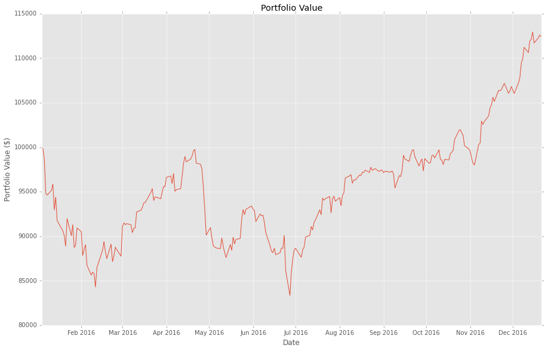

```python
%matplotlib inline
import matplotlib
import matplotlib.pyplot as plt
matplotlib.rcParams['figure.figsize'] = (15, 10)  #not needed in code


import numpy as np
import pandas as pd
import pandas_datareader.data as web

def get_adjusted_close(tickers,start,end):
    d = {} #our dictionary
    for ticker in tickers:
        d[ticker] = web.DataReader(ticker,"yahoo",start,end) #this will give us open, high, low, close, volume, Adj Close
    pan = pd.Panel(d)
    df_adj_close = pan.minor_xs('Adj Close')
    return df_adj_close

def Portfolio_Value(df_adj_close,weights,cash):
        normed = df_adj_close/df_adj_close.ix[0,:] #Norming the prices
        alloced = normed*weights #Creating our allocations
        pos_vals = alloced*cash  #Our portfolio value
        series_portfolio_value = pos_vals.sum(axis=1)  #Summing by row
        return series_portfolio_value


def Plot_Portfolio_Value(port_val):
        plt.style.use('ggplot')   #The style of our plot

        port_val = port_val.to_frame()
        dates =  port_val.index
        port_val = port_val.values
        fig = plt.figure()
        ax = fig.add_subplot(111)
        fig.subplots_adjust(top=0.85)

        #Setting our axis titles
        ax.set_title('Portfolio Value')
        ax.set_xlabel('Date')
        ax.set_ylabel('Portfolio Value ($)')

        #plotting our portfolio
        plt.plot(dates,port_val)
        return

tickers = ['AAPL','BAC','GILD','MSFT']
start = '2016-01-01'
end = '2016-12-21'
df_adj_close = get_adjusted_close(tickers,start,end)
weights = [0.25,0.25,0.25,0.25]
cash = 100000
pv = Portfolio_Value(df_adj_close,weights,cash)
Plot_Portfolio_Value(pv)
```

We can now see how our portfolio has performed over time.